# Causal Effect Estimation on Genotype Data: GLM, TMLE, and C-TMLE

Causality in Biomedicine: Going Beyond Associations (EMBL-EBI, 4-9 Oct 2026)

Asantewaa Sarpong & Sjoerd Beentjes

2026-10-03

## Purpose

In this notebook we estimate the **average treatment effect (ATE)** of a single genetic variant (SNP) on a simulated outcome, using three increasingly sophisticated estimators:

1. **GLM-based ATE**: a plain regression adjustment. Fast, simple, but relies on correctly specifying the outcome model.
2. **TMLE** (Targeted Maximum Likelihood Estimation): a doubly-robust, semiparametric estimator that combines flexible outcome and treatment (“propensity”) models.
3. **C-TMLE** (Collaborative TMLE): builds the propensity model *collaboratively* with the outcome model, rather than fitting it independently, which can help when candidate confounders are highly correlated (as genetic variants often are, due to linkage disequilibrium).

TMLE and C-TMLE here are **this project’s own implementations** (`src/estimators.R`, `src/utils.R`) , the same code used in the full simulation benchmark behind this repository, not the bare CRAN package functions. This matters: `estimators.R` builds in cross-fitting and a bootstrap-based standard error validated specifically for this genotype setting, and it defines its own function literally called `tmle()`, which is a different (and the one we actually want) implementation from the `tmle` package’s own `tmle()`.

We use the `data/geno.csv` genotype matrix from this repository, which is **fully synthetic**, no real individuals are involved.

Because the true treatment effect is known by construction in this exercise (we define it ourselves, below), you can directly compare each estimator’s output against the right answer.

A single estimate and CI only gets you so far, though: a 95% CI either happens to contain the truth on one dataset or it doesn’t, and that alone tells you almost nothing about whether the CI *method* is trustworthy. So after comparing the three estimators once (Section 6), we re-simulate the outcome several times and check **empirical coverage**: across repeated simulated datasets, how often does each estimator’s stated 95% CI actually contain the true ATE? That’s the real content of “quantifying uncertainty in simulations” (Section 7).

```r
# Sourcing estimators.R also sources utils.R (see its own source() call at
# the top of the file) and loads every package both files need internally
# (glmnet, glm2, caret, tibble, dplyr, tidyr, ggplot2, ctmle) — no separate
# library() calls needed here.
source("src/estimators.R")
```

## 1. Load the data and pick a treatment SNP

```r
geno <- read.csv("data/geno.csv", row.names = 1, check.names = FALSE)
geno <- as.matrix(geno)

dim(geno)   # samples x SNPs
```

```
## [1] 10000  1000
```

For this walkthrough we’ll treat one SNP as the “treatment” and a small set of nearby SNPs as potential confounders. In the full SIM2 study (see the project’s `data/` and `src/` folders) every one of 9 treatment SNPs is tested against ~199 confounders across 200 replicates , here we use far fewer of both, purely so each estimator fits in a few seconds during the session.

```r
treatment_snp    <- colnames(geno)[1]        # first SNP in the matrix
confounder_snps  <- colnames(geno)[2:21]     # next 20 SNPs as confounders

# Binary treatment: carries >=1 copy of the variant vs. none
A <- as.numeric(geno[, treatment_snp] > 0)

# IMPORTANT: this project's estimator functions (tmle(), ctmle1(), ...)
# all expect confounder columns named W1, W2, ... — .W_matrix() in
# utils.R picks them out with a "^W" regex. Using the raw SNP rsIDs as
# column names here would cause .W_matrix() to silently find ZERO
# confounder columns.
W <- as.data.frame(geno[, confounder_snps])
colnames(W) <- paste0("W", seq_len(ncol(W)))

table(A)
```

```
## A
##    0    1
## 5911 4089
```

## 2. Simulate a known-truth outcome

To actually demonstrate GLM’s limitations (not just assert them), the outcome needs to be something a plain `Y ~ A + W` GLM genuinely cannot represent, not just “nonlinear in W”, which turns out to barely bias GLM at all (see note below). The reliable mechanism is **effect modification**: we let the *treatment effect itself* vary with `W4`, a confounder in strong LD with (i.e. correlated with) the treatment SNP.

The population-average (marginal) ATE is still exactly **1** by construction, we center `W4` so its mean contribution is zero, but no single additive coefficient on `A` can capture an effect that genuinely differs by subgroup. If you’ve taken a GLM course, this is the single most important failure mode to know: an omitted `A:W` interaction biases the ATE whenever the modifying covariate correlates with treatment, which is exactly the situation genetic confounders are usually in.

```r
set.seed(42)

true_ate <- 1
effect_modifier_strength <- 0.5   # how much the treatment effect varies with W4

# Individual treatment effect varies with W4. Centering W4 keeps the
# population-average (marginal) ATE at exactly `true_ate`.
W4_centered <- W$W4 - mean(W$W4)
individual_effect <- true_ate + effect_modifier_strength * W4_centered

Y <- individual_effect * A +
  0.5 * W$W1 - 0.3 * W$W2 + 0.2 * W$W3 +
  rnorm(nrow(W), mean = 0, sd = 1)
```

> **Note on an earlier version of this DGM:** we originally tried adding interactions among confounders (`W x W`, no treatment involved) to break GLM’s linear specification. That turns out not to reliably bias GLM’s point estimate, once main effects are controlled for, a properly-scaled `W x W` interaction term ends up nearly uncorrelated with treatment, so GLM’s omitted-variable bias from it is small (this was a real, hard-won finding from the full simulation study behind this repo). Effect modification (`A x W`) is the more reliable demo because the omitted term directly involves treatment itself.

Every estimator below is given exactly the same input , a single data frame with columns `A`, `W1`…`W20`, and `Y` , matching the format this project’s pipeline uses throughout (see `ctmle_mc_analysis.R`).

```r
data <- data.frame(A = A, W, Y = Y)
```

## 3. GLM-based ATE

The simplest approach: regress the outcome on treatment and confounders, and read off the coefficient on `A`. There’s no project-specific GLM function for this , it’s intentionally just base R’s `glm()` , so this is the one estimator here that is *not* from `src/estimators.R`.

```r
glm_fit <- glm(Y ~ ., data = data, family = "gaussian")

glm_ate <- coef(glm_fit)["A"]
glm_se  <- summary(glm_fit)$coefficients["A", "Std. Error"]

cat(sprintf("GLM ATE estimate: %.3f (SE: %.3f)\n", glm_ate, glm_se))
```

```
## GLM ATE estimate: 0.957 (SE: 0.032)
```

**Discussion point:** `Y ~ .` fits one constant coefficient on `A`, it cannot represent a treatment effect that varies with `W4`, the way we just built into the data. Because `W4` correlates with treatment (strong LD with the treatment SNP), this constant-effect assumption produces real bias, not just extra noise. And critically: nothing about the GLM output above tells you this happened, the model fits “successfully” and reports a confident standard error regardless.

## 4. TMLE

TMLE improves on the GLM approach in two ways: it allows flexible, cross-fitted models for both the outcome and the propensity score, and it “targets” the outcome model to the parameter of interest (the ATE), giving an estimator that is **doubly robust** , consistent if *either* the outcome model or the propensity model is correctly specified, not necessarily both.

We call this project’s `tmle()` directly, with its production defaults: cross-fitted (“CV”) variance estimation, and a targeted bootstrap for the standard error (`n_boot = 200` resamples by default , if this feels slow on your machine during the session, try `n_boot = 50`).

> **Important, and worth saying out loud to participants:** this project’s `tmle()`/`ctmle1()` build their own outcome model the same way GLM does, main effects only, no `A:W4` interaction (see `.make_QX()` in `utils.R`). So they are not automatically immune to the effect-modification bias above. Their protection, if any, comes entirely from TMLE’s **doubly-robust** property: consistent if *either* the outcome model or the propensity model is correct, not necessarily both. Whether that actually rescues the estimate here is an empirical question, look at the bias numbers in Section 6, don’t assume the answer.

```r
tmle_fit <- tmle(data, alpha = 0.05)

tmle_ate <- tmle_fit$est
tmle_se  <- tmle_fit$se

cat(sprintf("TMLE ATE estimate: %.3f (95%% CI: %.3f, %.3f)\n",
            tmle_ate, tmle_fit$ci_lower, tmle_fit$ci_upper))
```

```
## TMLE ATE estimate: 0.955 (95% CI: 0.872, 1.026)
```

## 5. C-TMLE

C-TMLE is most useful when candidate confounders are highly correlated with each other or with treatment , exactly the situation genetic variants are often in, due to linkage disequilibrium. Rather than fitting the propensity model independently of the outcome model, C-TMLE builds it up collaboratively: here, via a LASSO path over the propensity model with the penalty strength chosen by targeted cross-validated loss, rather than ordinary predictive CV.

We use `ctmle1()`, this project’s primary C-TMLE variant (there are several others in `src/estimators.R` , `ctmle0()`, `scalable_ctmle()`, the Wang-CTMLE family , each making a different collaborative-selection choice; `ctmle1()` is the one used as the main comparison point throughout the SIM2 study).

```r
ctmle_fit <- ctmle1(data, alpha = 0.05)

ctmle_ate <- ctmle_fit$est
ctmle_se  <- ctmle_fit$se

cat(sprintf("C-TMLE ATE estimate: %.3f (95%% CI: %.3f, %.3f)\n",
            ctmle_ate, ctmle_fit$ci_lower, ctmle_fit$ci_upper))
```

```
## C-TMLE ATE estimate: 0.958 (95% CI: 0.879, 1.045)
```

## 6. Compare all three (single simulated dataset)

```r
results <- data.frame(
  Method   = c("GLM", "TMLE", "C-TMLE"),
  Estimate = c(glm_ate, tmle_ate, ctmle_ate),
  Bias     = c(glm_ate, tmle_ate, ctmle_ate) - true_ate
)

print(results, row.names = FALSE)
```

```
##  Method  Estimate        Bias
##     GLM 0.9570820 -0.04291804
##    TMLE 0.9546842 -0.04531584
##  C-TMLE 0.9584708 -0.04152922
```

**Quick check before moving on:** how close is each estimate to the true ATE of 1, and does each CI actually contain it? Keep this one run in mind as you look at the next section, since it’s just a single sample from the distribution of possible outcomes you’re about to generate.

## 7. Quantifying uncertainty: coverage across repeated simulations

A stated “95% CI” is a claim about long-run behaviour: *if we repeated this experiment many times, 95% of the resulting intervals would contain the true value.* We can actually check that claim here, because we know the true ATE by construction. We re-simulate the outcome `n_reps` times (same genotypes `A`/`W`, fresh random noise each time), refit all three estimators on each simulated dataset, and tally how often each one’s CI contains the true ATE of 1.

> **Timing note (read before running live):** `n_boot_mc` below is set well below the `tmle()`/`ctmle1()` production default of 200, to keep this loop fast enough for a live session. Time this cell yourself before the practical and adjust `n_reps`/`n_boot_mc` to fit your slot — we couldn’t benchmark exact runtime in advance.

```r
n_reps    <- 15   # number of simulated datasets
n_boot_mc <- 30    # bootstrap resamples per TMLE/C-TMLE fit (production default: 200)

run_one_replicate <- function(rep_id) {
  set.seed(1000 + rep_id)

  W4_centered <- W$W4 - mean(W$W4)
  individual_effect <- true_ate + effect_modifier_strength * W4_centered

  Y_rep <- individual_effect * A +
    0.5 * W$W1 - 0.3 * W$W2 + 0.2 * W$W3 +
    rnorm(nrow(W), mean = 0, sd = 1)

  data_rep <- data.frame(A = A, W, Y = Y_rep)

  glm_fit_rep <- glm(Y ~ ., data = data_rep, family = "gaussian")
  glm_est_rep <- unname(coef(glm_fit_rep)["A"])
  glm_se_rep  <- summary(glm_fit_rep)$coefficients["A", "Std. Error"]
  glm_ci_rep  <- glm_est_rep + c(-1, 1) * 1.96 * glm_se_rep

  tmle_fit_rep  <- tmle(data_rep, alpha = 0.05, n_boot = n_boot_mc)
  ctmle_fit_rep <- ctmle1(data_rep, alpha = 0.05, n_boot = n_boot_mc)

  data.frame(
    rep      = rep_id,
    Method   = c("GLM", "TMLE", "C-TMLE"),
    Estimate = c(glm_est_rep, tmle_fit_rep$est, ctmle_fit_rep$est),
    CI_Lower = c(glm_ci_rep[1], tmle_fit_rep$ci_lower, ctmle_fit_rep$ci_lower),
    CI_Upper = c(glm_ci_rep[2], tmle_fit_rep$ci_upper, ctmle_fit_rep$ci_upper)
  )
}
```

```r
mc_results <- do.call(rbind, lapply(seq_len(n_reps), run_one_replicate))

mc_results <- mc_results %>%
  mutate(
    bias   = Estimate - true_ate,
    covers = CI_Lower <= true_ate & CI_Upper >= true_ate
  )
```

```r
coverage_summary <- mc_results %>%
  group_by(Method) %>%
  summarise(
    mean_estimate       = mean(Estimate),
    mean_bias           = mean(bias),
    empirical_coverage  = mean(covers),
    .groups = "drop"
  )

print(coverage_summary, n = Inf)
```

```
## # A tibble: 3 × 4
##   Method mean_estimate mean_bias empirical_coverage
##   <chr>          <dbl>     <dbl>              <dbl>
## 1 C-TMLE         0.968   -0.0317              0.933
## 2 GLM            0.959   -0.0415              0.667
## 3 TMLE           0.968   -0.0322              0.867
```

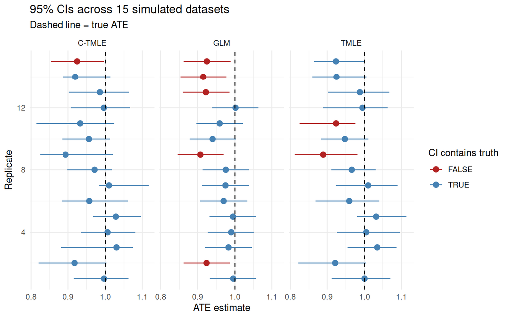

```r
ggplot(mc_results, aes(x = Estimate, y = rep, xmin = CI_Lower, xmax = CI_Upper,
                       colour = covers)) +
  geom_pointrange() +
  geom_vline(xintercept = true_ate, linetype = "dashed", colour = "black") +
  facet_wrap(~ Method) +
  scale_colour_manual(values = c(`TRUE` = "steelblue", `FALSE` = "firebrick"),
                      name = "CI contains truth") +
  labs(
    title    = sprintf("95%% CIs across %d simulated datasets", n_reps),
    subtitle = "Dashed line = true ATE",
    x = "ATE estimate", y = "Replicate"
  ) +
  theme_minimal()
```

**Discussion questions for participants:**

- With only 15 replicates, empirical coverage is a noisy estimate of true coverage; would you trust a difference of, say, 73% vs. 87% here as real, or is that within the noise you’d expect from this few replicates? (This is itself worth discussing: how many replicates would you want before trusting a coverage estimate?)
- Which estimator’s empirical coverage came closest to the nominal 95%? Did that match your expectation from the single-dataset comparison in Section 6?
- What happens if you pick a *different* treatment SNP, particularly one more strongly correlated with its neighbouring confounders? (Try changing `treatment_snp` back in Section 1 to a SNP from later in the matrix, and re-running from there.)
- The full simulation study behind this repository runs this same kind of comparison across 9 treatment SNPs spanning Strong/Moderate/Minimal linkage disequilibrium, with 200 replicates each (not 15), and finds that **confidence interval coverage degrades under strong LD** even when point estimates look reasonable. Given the mechanism you just built into this notebook’s DGM (effect modification correlated with treatment), does that finding make more sense now?